# STA380-HW1 Graves,He,Yu,Zhu

Mengnan He, Christina Graves, Liz(Zongyue) Yu, Alice(Yiqing) Zhu

August 7, 2016

## PartA & PartB

### **Part A**

We know:

P(Y)=0.65,P(N)=0.35 P(RC)=0.3,P(TC)=1-P(RC)=0.7 P(Y|RC)=P(N|RC)=0.5

So: P(Y)=P(Y|TC)*P(TC) + P(Y|RC)*P(RC) =P(Y|TC)*0.7 + 0.5*0.3 =P(Y|TC)*0.7 + 0.15$ =0.65

P(Y|TC)=(0.65-0.15)/0.7=0.7143

### **Part B**

Let A = {Has a disease}, B = {Test positive} We know: P(B|A) = 0.993 P(not B|not A) = 0.9999 P(A) = 0.000025$ P(A|B) = P(A) * P(B|A) / P(B) = P(A) * P(B|A) / (P(B|A) * P(A) + P(B|not A) * P(not A) P(B|not A) = 1 ?C P(not B|not A) = 1 ?C 0.9999 = 0.0001 P(A|B) = 0.000025 * 0.993 / (0.993 * 0.000025 + 0.0001 * (1-0.000025)) = 0.1989

## Exploratory Analysis: Green /Buildings

Because the on-staff guru did not account for other variables that may have contributed to the rise in the median rent price, there is the possibility of incorrectly concluding that a green certification will lead to the increase in rent price by $2.60 per square foot. After some exploratory data analysis, we found that an important variable affecting price that was not being controlled for was the quality classification of a building. It turns out that the classification of a building has a positive effect on rent price, with class A buildings having a higher median and mean price than the other classes. Although class A buildings comprise only 40% of the entire data set, they comprise 80% of green certified buildings which may have skewed the data observed by the on-staff guru. In effect, the increase in the median price of rent was likely due to in large part to the high proportion of class A buildings in the subset of green buildings. If the classification of a building is controlled for, then the results of median and mean of the data differ significantly from the guru???s initial findings.

[output not shown]

The median of buildings that are not Class A is $23.50

```
##    Min. 1st Qu.  Median    Mean 3rd Qu.    Max.
##    2.98   18.00   23.50   25.82   31.51  200.00
```

The median of buildings that are Class A is $28.20.

```
##    Min. 1st Qu.  Median    Mean 3rd Qu.    Max.
##    8.87   21.69   28.20   32.32   38.00  250.00
```

Class A buildings have a median rent price per square foot that is $4.70 higher than other buildings. Thus, an increase in rent due to classification likely had an effect on the guru’s observation of an increase in rent due to green certification.

**Contingency Table: Number of Green Certified Buildings that are Class A**  
This table shows that the majority of green-certified buildings are class A buildings. Out of 685 total green-certified buildings, 546 are classified as class A buildings.

```
##             class_a
## green_rating    0    1
##            0 4598 2611
##            1  139  546
```

**Contingency Table: Proporation of Green Buildings that are Class A**  
As indicated by this proportion table, Class A buildings comprise about 80% of all green-certified buildings.

```
##             class_a
## green_rating         0         1
##            0 0.6378138 0.3621862
##            1 0.2029197 0.7970803
```

**Effect of Green Rating and Classification on Rent**  
These two box plots are designed to show to that both green certification and the classification of a building have a similar positive effect on rent. This is important to show that classification should be observed and controlled in order to show the true effects of a green rating on rent price.

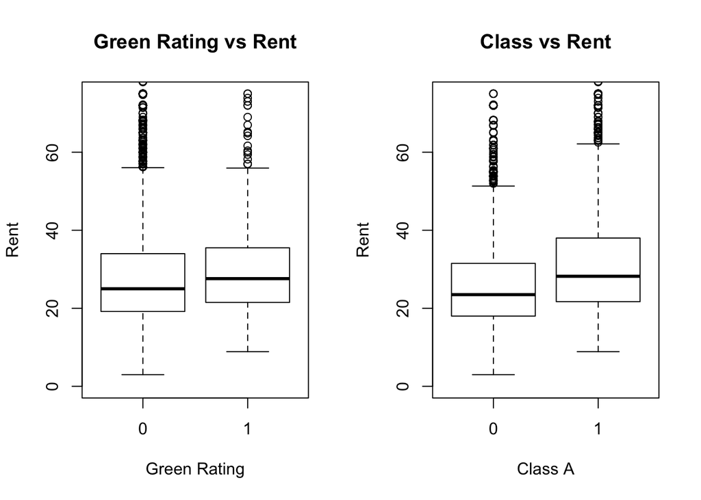

**Effect of Green Certification on Class A Buildings**  
As can be observed by the summary statistics and the box plot below, Green Rating does not have as great as effect on rent as the guru concluded when the classification of an “A” building is controlled for.

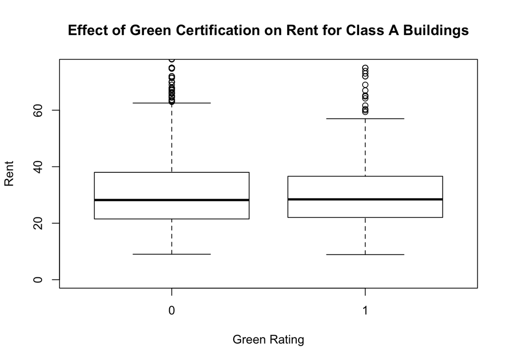

Median of Class A building rent without green certification: $28.20

```
## [1] 28.2
```

Median of Class A building rent with green certification: $28.44

```
## [1] 28.44
```

In conclusion, we do not believe the guru was correct in concluding that being green certified will automatically lead to a $2.60 per square foot increase in rent price and subsequently basing all of his profit estimates on this number. Classification of a building is a significant factor that should to be considered when calculating the potential increased profits of becoming green certified. If a building is considered class A, the increased rent price per square foot is only expected to increase by $0.24 which may not be worth the costs for the company (this number is based on the median prices of rent; if we are to look at the mean, rent price is actually expected to decrease by $1.60).

## Bootstrapping

### 0 Preparation

We import daily return data of the five assets from Yahoo Finance. The start date is 2004-12-01, which is almost the earliest date to retrieve available data for all the five assets.

Then we introduce a helper function for calculating daily returns from Yahoo price series.

### 1 Marshal appropriate evidence to characterize the risk/return properties of the five major asset classes.

There are sevreal factors that we can look into in order to characterize the risk/return properties of the five major asset classes.

- **Plots of Daily Returns on Time Series**

We use S&P500 performance as an indicator of market performance. Also, return on 20+ year US treasury bond is treated as risk free rate in our comparison and calculation.

We can see from the following plots that returns of LQD are less volatile than EEM and VNQ. The fluctuation range of EEM is wider than VNQ. We may conclude that LQD has lower risk and thus lower return. While emerging markets and real estate are more vulnerable, EEM and VNQ are riskier and will generate high returns.

20-year US Treasury bonds can generally be seen as risk free assets. They are very safe and have stable low returns.

S&P 500 can be set as a good benchmark to capture the market performance. It has moderate risk and returns.

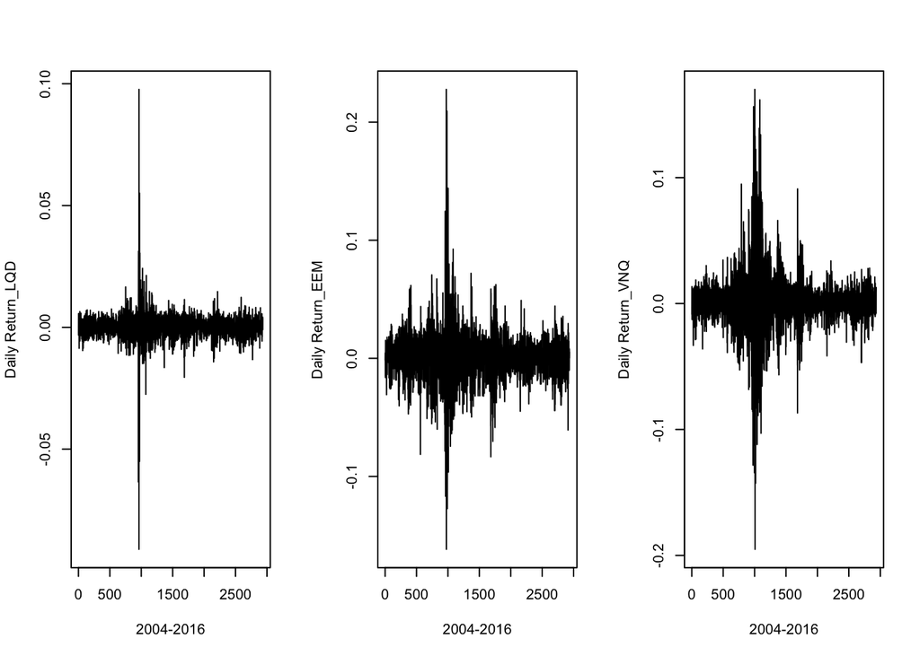

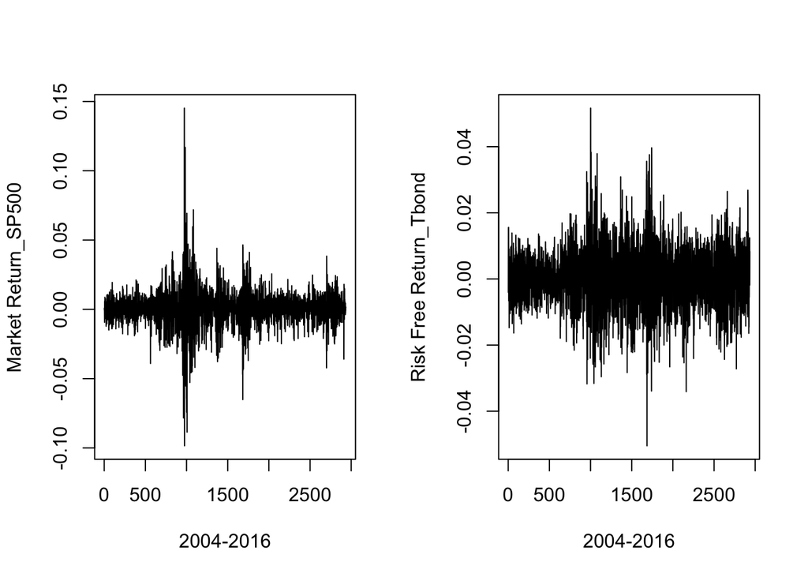

- **Mean and Standard Deviation**

Mean and standard deviation of returns respectively represent the asset’s overall return and risk during a certain period of time.

We also calculate the mean and sd of return premium of each assets over risk free rates for the sharpe ratio calculation.

- **Sharp Ratio**

Sharpe ratio measures average return earned in excess of the risk-free rate per unit of volatility. It’s a risk adjusted return.

- **CAPM Alpha and Beta**
- **Beta**: It is the sensitivity of an asset’s excess return to the excess market return.
- **Alpha**: Alpha coefficient indicates how an investment has performed after accounting for the risk it involved: alpha<0: the investment has earned too little for its risk; alpha=0: the investment has earned a return adequate for the risk taken; alpha>0: the investment has a return in excess of the reward for the assumed risk.

SPY clearly has a beta of 1 as SPY return serves as the market return based on our assumption.

From the results below, LQD is not very sensitive to the market performance and earned less for its risk. VNQ and EEM are more volatile than the market as they both have betas above 1. EEM is 26% more volative than market, while VNQ is 15% more volatile than market. They also have positive alphas, which shows that they have returns in excess of the reward for the assumed risk.

```
##
## Call:
## lm(formula = myreturns[, 7] ~ myreturns[, 6])
##
## Residuals:
##       Min        1Q    Median        3Q       Max
## -0.082435 -0.002092 -0.000104  0.002171  0.099134
##
## Coefficients:
##                  Estimate Std. Error t value Pr(>|t|)
## (Intercept)    -1.260e-04  9.721e-05  -1.296    0.195
## myreturns[, 6]  3.504e-01  5.346e-03  65.535   <2e-16 ***
## ---
## Signif. codes:  0 '***' 0.001 '**' 0.01 '*' 0.05 '.' 0.1 ' ' 1
##
## Residual standard error: 0.005266 on 2933 degrees of freedom
## Multiple R-squared:  0.5942, Adjusted R-squared:  0.5941
## F-statistic:  4295 on 1 and 2933 DF,  p-value: < 2.2e-16
```

```
##
## Call:
## lm(formula = myreturns[, 8] ~ myreturns[, 6])
##
## Residuals:
##       Min        1Q    Median        3Q       Max
## -0.071186 -0.005651 -0.000133  0.005861  0.088811
##
## Coefficients:
##                 Estimate Std. Error t value Pr(>|t|)
## (Intercept)    8.913e-05  1.896e-04    0.47    0.638
## myreturns[, 6] 1.263e+00  1.043e-02  121.11   <2e-16 ***
## ---
## Signif. codes:  0 '***' 0.001 '**' 0.01 '*' 0.05 '.' 0.1 ' ' 1
##
## Residual standard error: 0.01027 on 2933 degrees of freedom
## Multiple R-squared:  0.8333, Adjusted R-squared:  0.8333
## F-statistic: 1.467e+04 on 1 and 2933 DF,  p-value: < 2.2e-16
```

```
##
## Call:
## lm(formula = myreturns[, 9] ~ myreturns[, 6])
##
## Residuals:
##       Min        1Q    Median        3Q       Max
## -0.114732 -0.005681  0.000012  0.005836  0.122402
##
## Coefficients:
##                 Estimate Std. Error t value Pr(>|t|)
## (Intercept)    0.0002149  0.0002529    0.85    0.396
## myreturns[, 6] 1.1574405  0.0139110   83.20   <2e-16 ***
## ---
## Signif. codes:  0 '***' 0.001 '**' 0.01 '*' 0.05 '.' 0.1 ' ' 1
##
## Residual standard error: 0.0137 on 2933 degrees of freedom
## Multiple R-squared:  0.7024, Adjusted R-squared:  0.7023
## F-statistic:  6923 on 1 and 2933 DF,  p-value: < 2.2e-16
```

```
##    (Intercept) myreturns[, 6]
##  -0.0001259692   0.3503599960
```

```
##    (Intercept) myreturns[, 6]
##   0.0000891291   1.2625546511
```

```
##    (Intercept) myreturns[, 6]
##   0.0002149272   1.1574405155
```

### 2 Outlines your choice of the “safe” and “aggressive” portfolios.

**1. Safe Portfolio**

We choose S&P 500, T bond and investment grade corporate bond for the safe portfolio as they have relatively lower risk when compared to the other two. S&P500 and investment grade corporate bond are given 30% weights each.T bond weighs 40% in the portfolio.

**2. Aggressive Portfolio**

Risky assets should be included in this portfolio. Thus, we put 50% EEM and 50% VNQ in it.

### 3 Monte Carlo Simulation

Use bootstrap resampling to estimate the 4-week (20 trading day) value at risk of each of your three portfolios at the 5% level.

**1. Evenly Split Portfolio**

```
##        5%
## -6000.922
```

**2. Safe Portfolio**

```
##        5%
## -2948.806
```

**3. Agressive Portfolio**

```
##        5%
## -12524.33
```

### 4 Compare the results for each portfolio in a way that would allow the reader to make an intelligent decision among the three options.

- **Total Wealth Histogrm**

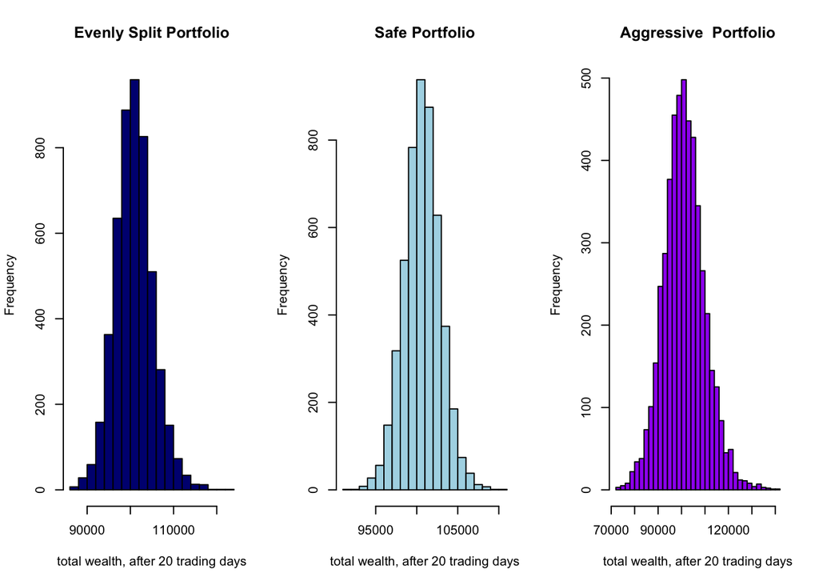

- **Profit/Loss Histogram**

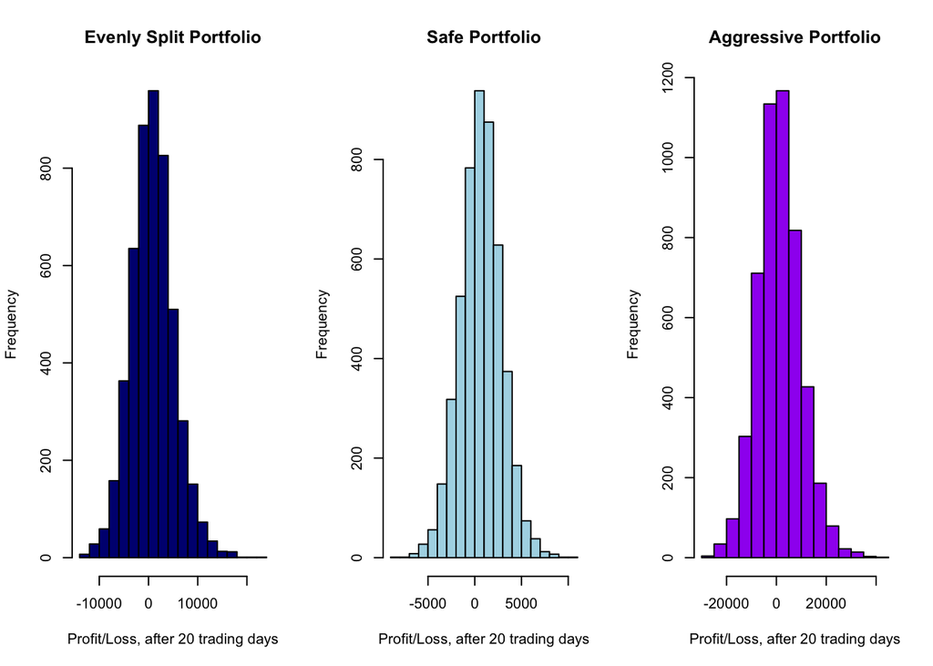

- **Mean and Variance**

Mean and variance of portfolio returns respectively reflect the return level and risk level. The results below are in accordance with the histogram results that were presented above.

```
##      mean.evenly mean.safe mean.aggressive
## [1,]    100870.6  100670.2        101188.1
```

```
##      sd.evenly  sd.safe sd.aggressive
## [1,]  4406.727 2222.119      8737.723
```

- **Investment suggestion**

Risk averse investors may be interseted in the safe portfolio, while risk appetite investor will want to invest in the aggressive portfolio.

## Market Segmentation

**1) Overview**

Behavioral segmentation divides consumers into groups according to their knowledge of, attitude towards, usage rate, response. Many marketers believe that behavior variables are the best starting point for building market segments[1]. In this particular problem, we would like to knwo if marketers can group customers based on information hidden in their tweets.

What we try to find is evidence for:

- Latent factors
- Clusters

**2) Data and models**

Our data on social media marketing are the numbers of tweets belong to 36 different categories from 7882 users. The first column called X indicates unique user ids and the rest columns are categories, each representing a broad area of interest (e.g. politics, sports, family, etc.).

```
##  [1] "X"                "chatter"          "current_events"
##  [4] "travel"           "photo_sharing"    "uncategorized"
##  [7] "tv_film"          "sports_fandom"    "politics"
## [10] "food"             "family"           "home_and_garden"
## [13] "music"            "news"             "online_gaming"
## [16] "shopping"         "health_nutrition" "college_uni"
## [19] "sports_playing"   "cooking"          "eco"
## [22] "computers"        "business"         "outdoors"
## [25] "crafts"           "automotive"       "art"
## [28] "religion"         "beauty"           "parenting"
## [31] "dating"           "school"           "personal_fitness"
## [34] "fashion"          "small_business"   "spam"
## [37] "adult"
```

In order to find patterns for latent factors and clusters, we fit two unsupervised models, Principle Components Analysis (PCA) and K-means, to see if there were any suggestion about important categories or clear customer group.

**3) Results**

- *PCA*

The summary on PCA indicates how much variance of the data set can each principal component explain and cumulative propotion for all components. We can see that PC1 explains 12.68% of total variances, which is the highest among all. Also, the marginal increase of information is not very much when adding a new variable, due to the fact that the first half number of variables can explain 80% variances.

```
## Importance of components:
##                           PC1     PC2     PC3    PC4     PC5     PC6
## Standard deviation     2.1062 1.67935 1.59142 1.5302 1.46802 1.29291
## Proportion of Variance 0.1268 0.08058 0.07236 0.0669 0.06157 0.04776
## Cumulative Proportion  0.1268 0.20732 0.27969 0.3466 0.40816 0.45592
##                            PC7     PC8     PC9    PC10    PC11   PC12
## Standard deviation     1.21842 1.17785 1.15073 1.05944 1.00564 0.9650
## Proportion of Variance 0.04242 0.03964 0.03783 0.03207 0.02889 0.0266
## Cumulative Proportion  0.49834 0.53798 0.57581 0.60788 0.63678 0.6634
##                          PC13   PC14    PC15    PC16    PC17    PC18
## Standard deviation     0.9613 0.9411 0.93288 0.91529 0.89738 0.85336
## Proportion of Variance 0.0264 0.0253 0.02486 0.02394 0.02301 0.02081
## Cumulative Proportion  0.6898 0.7151 0.73995 0.76389 0.78690 0.80770
##                           PC19    PC20   PC21    PC22    PC23    PC24
## Standard deviation     0.83074 0.80523 0.7531 0.69377 0.68444 0.65244
## Proportion of Variance 0.01972 0.01853 0.0162 0.01375 0.01338 0.01216
## Cumulative Proportion  0.82742 0.84595 0.8621 0.87590 0.88929 0.90145
##                           PC25    PC26   PC27    PC28    PC29    PC30
## Standard deviation     0.64787 0.63658 0.6317 0.61502 0.59912 0.59393
## Proportion of Variance 0.01199 0.01158 0.0114 0.01081 0.01026 0.01008
## Cumulative Proportion  0.91344 0.92502 0.9364 0.94723 0.95748 0.96756
##                           PC31    PC32    PC33    PC34    PC35
## Standard deviation     0.55072 0.48445 0.47749 0.43760 0.42169
## Proportion of Variance 0.00867 0.00671 0.00651 0.00547 0.00508
## Cumulative Proportion  0.97623 0.98293 0.98945 0.99492 1.00000
```

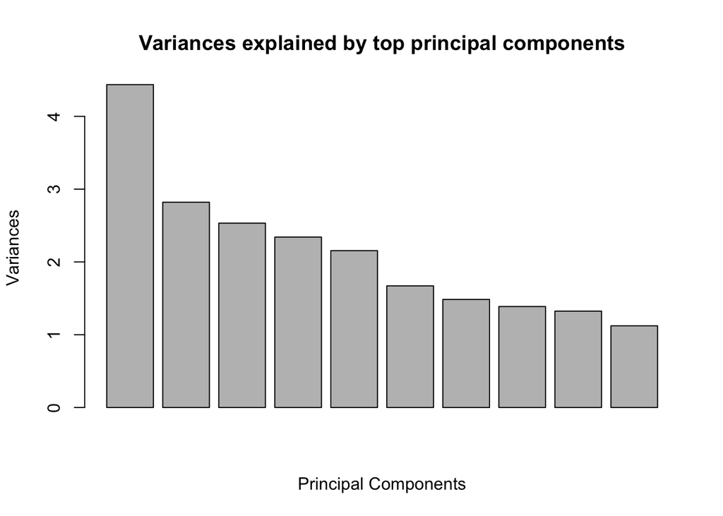

However, contribution of variance explanation made by the majority of features appears to be quite even, so we cannot conclude a latent factor from PCA. That is, no specific category or combination of categories manage to reflect users’ common topics.

```
##   current_events           travel    photo_sharing    uncategorized
##      1.526262370      1.585003806      2.696777468      0.812991626
##          tv_film    sports_fandom         politics             food
##      1.070286729      1.594011672      1.788632327      1.397487947
##           family  home_and_garden            music             news
##      0.863867039      0.520680030      0.679269221      1.205531591
##    online_gaming         shopping health_nutrition      college_uni
##      1.208830246      1.389368181      2.567241817      1.549479827
##   sports_playing          cooking              eco        computers
##      0.639177874      1.998223801      0.512306521      0.649073839
##         business         outdoors           crafts       automotive
##      0.423242832      0.782669373      0.515858919      0.829865516
##              art         religion           beauty        parenting
##      0.724816037      1.095407257      0.705150977      0.921339761
##           dating           school personal_fitness          fashion
##      0.710860188      0.767698554      1.462065466      0.996574473
##   small_business             spam            adult
##      0.336335955      0.006470439      0.403324029
```

We then start to look for evidence that market segments can be users sharing similar tweet posting behavior, in terms of topics posted.

- *K-means*

As a clustering method, K-means is used to group obervations into subsets. Here we choose the default euclidian distance, centers = 5 and nstart = 10 to fit K-means.

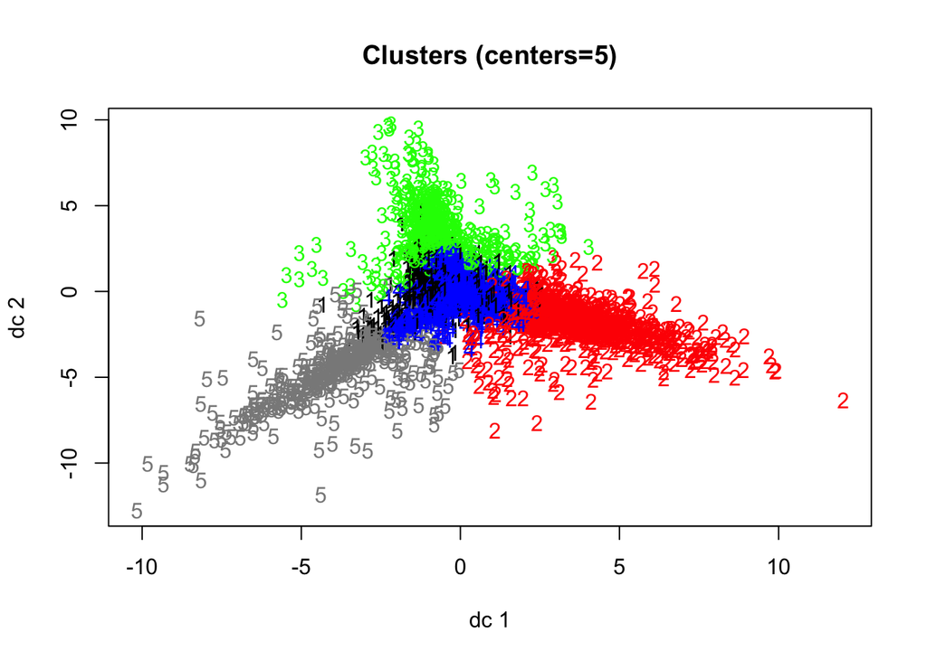

From the plot, K-means captures features quite well, with three “tails” being fully detected. We will then look into different cluster centers to see which unique characteristics each cluster have.

```
##    chatter current_events   travel photo_sharing uncategorized  tv_film
## 1 9.647224       1.869290 1.767393      5.493324     0.8973999 1.111736
## 2 4.031159       1.540409 1.490750      2.425511     0.9561831 1.060370
## 3 3.989031       1.723949 1.639854      5.866545     1.1974406 1.000000
## 4 2.889462       1.397309 1.537220      1.485426     0.7017937 1.033632
## 5 4.080000       1.442353 1.632941      2.621176     0.8564706 1.430588
##   sports_fandom politics     food    family home_and_garden     music
## 1      1.711876 2.413212 1.297259 1.0281096       0.5973296 0.7814476
## 2      1.512171 1.567673 2.269718 0.9074976       0.6280428 0.7517040
## 3      1.564899 1.590494 1.287020 0.9670932       0.6179159 1.1974406
## 4      1.573991 1.692377 1.233408 0.7621076       0.4551570 0.5578475
## 5      1.644706 1.496471 1.489412 1.1435294       0.5670588 0.7694118
##       news online_gaming shopping health_nutrition college_uni
## 1 1.323963     0.7905833 3.444132        1.2649332   1.2452565
## 2 1.311587     0.9357352 1.328140       12.1528724   1.0584226
```

[output cut: 27 more lines]

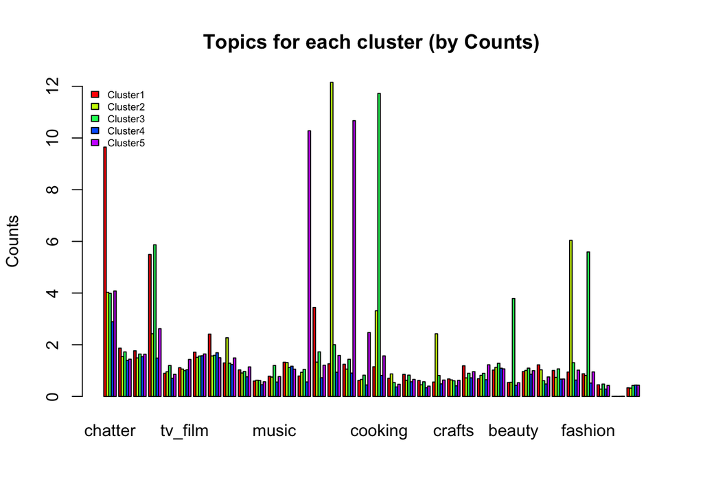

Based the table and plot above, we conclude on what these users truly look like:

- **Cluster 1: “Internet Celebrities”**

Feature columns: chatter, photo sharing and shopping

Internet Celebrities are famous for their activeness online, even if their post are simply chatting or photos about their lives. Having adequate exposure to the public is their own way of maintaining popularity. So we have fair reason to believe cluster 1 is the group of heavy internet users.

Besides, they also have the highest score on “politics” among all clusters, probably because they sometimes use their popularity for political events or on the other hand, make fun of politicians.

- **Cluster 2: “Body builders”**:

Feature columns: health&nutrition, outdoor and personal fitness

This cluster is the easiest to find, because topics these users care belong in similar categories: health and fitness. Being highly self-disciplined on foods and exercises make them keep great body shape. The fact that they posted a lot more about health than others may be explained by some mobile App automatically sending posts about users’ daily exercises attendency.

- **Cluster 3: “Young girls”**:

Feature columns: cooking, fashion and beauty

Needless to explain, here we have all the things young girls care about: cooking, fashion and beauty. This one is easy to tell as well.

- **Cluster 4: “The general public”**:

No specific feature column but are about average in each category

Cluster 4 is a somehow tricky. Unlike any cluster else, it has no noticable outlier in any column. However, it just represents every ordinary person - repost all kinds of stuff, but are far from being addicted to a certain topic. They are probably a little aged, gradually focusing on real lives instead of the virtual world.

- **Cluster 5: “College gamers”**:

Feature columns: college&university and online gaming

Cluster 5 seems to be a contraditory group - they care about getting into college and play online game at the same time. At first, this can be difficult to understand. Our thought is that perhaps the word “online gaming” does not necessarily mean being professional gamers. Sometimes people are attracted to play popular games and tweet about them (like the recent Pokemon Go!). So this group may also be high school or college students who love to play up-to-date games.

Although directly clustering the original data works very well, we have another hypothesis that topic percentage of each user may give different results. So we divide every cell with sum of numbers in that row to get the percentage of each topic among posts, then fit another K-means with other parameters being the same. The goal is to confirm our clustering results.

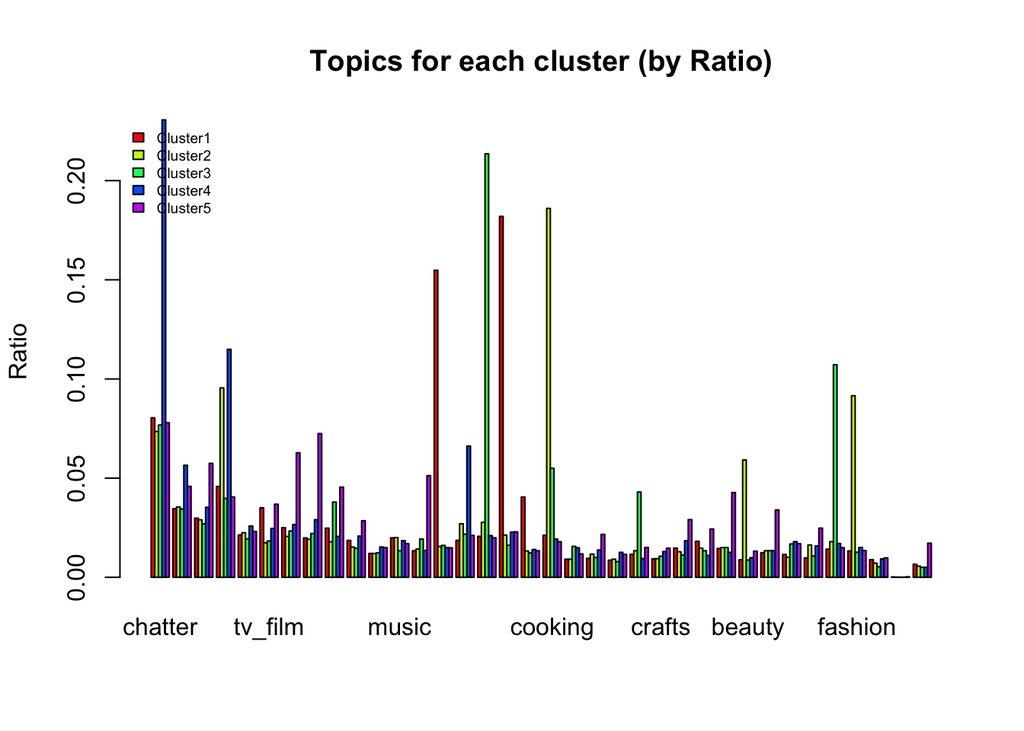

It turns out to have similar patterns as the previous K-means. So we are now further convinced with the segments extracted by clustering.

**4) Conclusion**

We have so far adopted PCA and K-means in dealing with social media data, clearly discovering how different user groups are. The five segments we find are:

- **“Internet Celebrities”**
- **“Body builders”**
- **“Young girls”**
- **“The general public”**
- **“College gamers”**

Due to omission of demographical information in this data set, we are unable to do further validation about our assumption on clusters. If supporting analysis are to be made in the future, as marketers, we surely can strategize more specific marketing plans to cater each group of users’ demands.

**Reference:**

[1]Philip Kotler and Gary Armstrong : Principles of Marketing Pearson Education Limited 2014, 2012